# 4-3. 데이터 분석 1차 - 모델링 및 평가

### 모델링 개요

앞선 과정에서 일련의 기준에 따라 챔피언들을 분류하고, 라벨링을 하였다. 이 결과를 가지고 각 게임에 참여한 챔피언들과 양 팀의 승패여부를 학습시켜 게임의 승패를 예측하는 모델을 작성하고자 한다.

입력변수는 챔피언의 여러 특성을 반영한 명목변수들이 될 것이며, 목적변수는 양 팀의 승패여부이다. 이번 모델링에 사용될 알고리즘은 RNN(순환신경망)이다.

순환신경망은 주로 시계열분석이나 텍스트분석에 흔히 쓰이는 딥러닝 알고리즘중 하나로, 승률 예측 모델에서 주어지는 입력변수에 양 팀의 포지션별 챔프간 시너지나 여타 상호작용들이 텍스트에서 보여지는 패턴과 유사할 것이라 판단되어 이 모델을 채택하게 되었다.

```python
import pandas as pd
import numpy as np
import matplotlib.pyplot as plt
import seaborn as sns
# 경고메세지 무시
import warnings
warnings.filterwarnings('ignore')
```

#### 매치데이터를 양 팀별/포지션별 챔피언 구성과 승패여부로 정렬

```python
# 기존에 정제한 데이터 로드
import pickle

with open("dataV3_processed.pickle","rb") as fr:
    df = pickle.load(fr)
df.head()
```

| matchId | gameDuration | assists | championName | damageDealtToObjectives | damageDealtToTurrets | damageSelfMitigated | deaths | dragonKills | kills | magicDamageDealtToChampions | ... | teamPosition | timeCCingOthers | totalDamageDealtToChampions | totalDamageShieldedOnTeammates | totalDamageTaken | totalHealsOnTeammates | totalMinionsKilled | trueDamageDealtToChampions | visionScore | win |
| --- | --- | --- | --- | --- | --- | --- | --- | --- | --- | --- | --- | --- | --- | --- | --- | --- | --- | --- | --- | --- | --- |
| KR_5944529373 | 1548 | 2 | Trundle | 10809 | 8068 | 14206 | 4 | 1 | 4 | 2200 | ... | TOP | 16 | 17912 | 0 | 22268 | 0 | 199 | 1251 | 11 | False |
| KR_5944529373 | 1548 | 5 | Viego | 12425 | 647 | 13265 | 5 | 0 | 3 | 1112 | ... | JUNGLE | 14 | 10543 | 0 | 20618 | 0 | 37 | 799 | 24 | False |
| KR_5944529373 | 1548 | 1 | Katarina | 4894 | 0 | 13089 | 6 | 0 | 7 | 14299 | ... | MIDDLE | 1 | 19362 | 0 | 22430 | 0 | 142 | 426 | 20 | False |
| KR_5944529373 | 1548 | 2 | Tristana | 334 | 248 | 8841 | 6 | 0 | 5 | 1986 | ... | BOTTOM | 2 | 10721 | 0 | 19263 | 0 | 168 | 588 | 24 | False |
| KR_5944529373 | 1548 | 9 | Nautilus | 5165 | 0 | 21768 | 7 | 0 | 0 | 4585 | ... | UTILITY | 59 | 7656 | 536 | 19286 | 0 | 32 | 461 | 48 | False |

5 rows × 22 columns

#### 데이터구조

- 한 매치당 10명의 챔피언(행)
- 양 팀별로 5명의 챔피언, 5명의 포지션
- 각 포지션에 대응되는 챔피언을 미리 라벨링 해 둔 결과로 대체
- 같은 챔피언이라도 포지션이 다르면 라벨링 결과가 달라짐

```python
# 피봇테이블
df_byTeam = pd.pivot_table(df,index=['matchId','win'],columns='teamPosition',values='championName',aggfunc='sum')
df_byTeam.head() # 한 매치당 승리팀,패배팀, 컬럼으로 포지션 구분
```

| matchId | teamPosition win | BOTTOM | JUNGLE | MIDDLE | TOP | UTILITY |
| --- | --- | --- | --- | --- | --- | --- |
| KR_5944529373 | False | Tristana | Viego | Katarina | Trundle | Nautilus |
|  | True | Zeri | Graves | Sett | Gwen | Zilean |
| KR_5944532797 | False | Lucian | MonkeyKing | Ahri | Garen | Zilean |
|  | True | Jinx | Evelynn | Vladimir | Olaf | Seraphine |
| KR_5944532993 | False | MissFortune | Kindred | Leblanc | Malphite | Nautilus |

```python
# 팀별, 포지션별 챔피언 df저장
import pickle

with open("df_byTeam.pickle","wb") as fw:
    pickle.dump(df_byTeam, fw)
```

```python
df_byTeam.isnull().sum() # 결측치 확인
```

```
teamPosition
BOTTOM     0
JUNGLE     0
MIDDLE     0
TOP        0
UTILITY    0
dtype: int64
```

```python
df_byTeam.columns # 컬럼명 확인
```

```
Index(['BOTTOM', 'JUNGLE', 'MIDDLE', 'TOP', 'UTILITY'], dtype='object', name='teamPosition')
```

```python
# 포지션별 챔피언 라벨링 결과 로드
with open("label_top.pickle","rb") as fr:
    label_top = pickle.load(fr)
with open("label_jgl.pickle","rb") as fr:
    label_jgl = pickle.load(fr)
with open("label_mid.pickle","rb") as fr:
    label_mid = pickle.load(fr)
with open("label_bot.pickle","rb") as fr:
    label_bot = pickle.load(fr)
with open("label_sup.pickle","rb") as fr:
    label_sup = pickle.load(fr)
```

```python
e = label_top.reset_index() # 인덱스로 활용되던 챔피언명을 값으로 활용
label_top = e.rename(columns={'index':'TOP'}) # 컬럼명 수정
label_top.head()
```

|  | TOP | top_minor | top_tank | top_deal | top_ap | top_ad | top_sp | top_tf |
| --- | --- | --- | --- | --- | --- | --- | --- | --- |
| 0 | Aatrox | 0 | 1.0 | 0.0 | 0.0 | 1.0 | 0.0 | 1.0 |
| 1 | Darius | 0 | 1.0 | 0.0 | 0.0 | 1.0 | 1.0 | 0.0 |
| 2 | Gangplank | 0 | 0.0 | 1.0 | 0.0 | 1.0 | 1.0 | 0.0 |
| 3 | Fiora | 0 | 1.0 | 0.0 | 0.0 | 1.0 | 1.0 | 0.0 |
| 4 | Renekton | 0 | 1.0 | 0.0 | 0.0 | 1.0 | 1.0 | 0.0 |

```python
# 나머지 포지션 라벨에도 동일하게 적용
label_jgl = label_jgl.reset_index().rename(columns={'index':'JUNGLE'})
label_mid = label_mid.reset_index().rename(columns={'index':'MIDDLE'})
label_bot = label_bot.reset_index().rename(columns={'index':'BOTTOM'})
label_sup = label_sup.reset_index().rename(columns={'index':'UTILITY'})
```

```python
label_sup.head() # 데이터 확인
```

|  | UTILITY | sup_비주류 | sup_util | sup_tank | sup_deal_ap | sup_deal_ad |
| --- | --- | --- | --- | --- | --- | --- |
| 0 | Ezreal | 1 | 0 | 0 | 0 | 0 |
| 1 | Kaisa | 1 | 0 | 0 | 0 | 0 |
| 2 | LeeSin | 1 | 0 | 0 | 0 | 0 |
| 3 | Sylas | 0 | 0 | 0 | 1 | 0 |
| 4 | Ashe | 0 | 0 | 0 | 0 | 1 |

```python
# 탑 챔피언명을 라벨로 대체
# df_byTeam에 label_top을 레프트 조인
labeledData = pd.merge(left=df_byTeam, right=label_top, how='left', on='TOP')
labeledData.head() # 결과 확인
```

|  | BOTTOM | JUNGLE | MIDDLE | TOP | UTILITY | top_minor | top_tank | top_deal | top_ap | top_ad | top_sp | top_tf |
| --- | --- | --- | --- | --- | --- | --- | --- | --- | --- | --- | --- | --- |
| 0 | Tristana | Viego | Katarina | Trundle | Nautilus | 0 | 1.0 | 0.0 | 0.0 | 1.0 | 1.0 | 0.0 |
| 1 | Zeri | Graves | Sett | Gwen | Zilean | 0 | 0.0 | 1.0 | 1.0 | 0.0 | 1.0 | 0.0 |
| 2 | Lucian | MonkeyKing | Ahri | Garen | Zilean | 0 | 1.0 | 0.0 | 0.0 | 1.0 | 1.0 | 0.0 |
| 3 | Jinx | Evelynn | Vladimir | Olaf | Seraphine | 0 | 0.0 | 1.0 | 0.0 | 1.0 | 1.0 | 0.0 |
| 4 | MissFortune | Kindred | Leblanc | Malphite | Nautilus | 0 | 1.0 | 0.0 | 1.0 | 0.0 | 0.0 | 1.0 |

```python
# 나머지 포지션에도 적용
labeledData = pd.merge(left=labeledData, right=label_jgl, how='left', on='JUNGLE')
labeledData = pd.merge(left=labeledData, right=label_mid, how='left', on='MIDDLE')
labeledData = pd.merge(left=labeledData, right=label_bot, how='left', on='BOTTOM')
labeledData = pd.merge(left=labeledData, right=label_sup, how='left', on='UTILITY')
labeledData.head(10) # 결과 확인
# 2행이 1게임 / 짝수행이 패배팀, 홀수행이 승리팀
```

|  | BOTTOM | JUNGLE | MIDDLE | TOP | UTILITY | top_minor | top_tank | top_deal | top_ap | top_ad | ... | bot_ad | bot_ap | bot_outboxer | bot_rush | bot_infight | sup_비주류 | sup_util | sup_tank | sup_deal_ap | sup_deal_ad |
| --- | --- | --- | --- | --- | --- | --- | --- | --- | --- | --- | --- | --- | --- | --- | --- | --- | --- | --- | --- | --- | --- |
| 0 | Tristana | Viego | Katarina | Trundle | Nautilus | 0 | 1.0 | 0.0 | 0.0 | 1.0 | ... | 1 | 0 | 0 | 0 | 1 | 0 | 0 | 1 | 0 | 0 |
| 1 | Zeri | Graves | Sett | Gwen | Zilean | 0 | 0.0 | 1.0 | 1.0 | 0.0 | ... | 1 | 0 | 0 | 0 | 1 | 0 | 1 | 0 | 0 | 0 |
| 2 | Lucian | MonkeyKing | Ahri | Garen | Zilean | 0 | 1.0 | 0.0 | 0.0 | 1.0 | ... | 1 | 0 | 0 | 0 | 1 | 0 | 1 | 0 | 0 | 0 |
| 3 | Jinx | Evelynn | Vladimir | Olaf | Seraphine | 0 | 0.0 | 1.0 | 0.0 | 1.0 | ... | 1 | 0 | 1 | 0 | 0 | 0 | 1 | 0 | 0 | 0 |
| 4 | MissFortune | Kindred | Leblanc | Malphite | Nautilus | 0 | 1.0 | 0.0 | 1.0 | 0.0 | ... | 1 | 0 | 1 | 0 | 0 | 0 | 0 | 1 | 0 | 0 |
| 5 | Kaisa | Viego | Karma | Camille | Leona | 0 | 1.0 | 0.0 | 0.0 | 1.0 | ... | 1 | 0 | 0 | 0 | 1 | 0 | 0 | 1 | 0 | 0 |
| 6 | Lucian | Sejuani | Katarina | Kassadin | Pyke | 1 | 0.0 | 0.0 | 0.0 | 0.0 | ... | 1 | 0 | 0 | 0 | 1 | 0 | 0 | 0 | 0 | 1 |
| 7 | Kaisa | MonkeyKing | Lissandra | Swain | Nautilus | 0 | 0.0 | 1.0 | 1.0 | 0.0 | ... | 1 | 0 | 0 | 0 | 1 | 0 | 0 | 1 | 0 | 0 |
| 8 | Twitch | Talon | Yasuo | Riven | Morgana | 0 | 1.0 | 0.0 | 0.0 | 1.0 | ... | 1 | 0 | 0 | 0 | 1 | 0 | 0 | 0 | 1 | 0 |
| 9 | Draven | Poppy | Zoe | Rumble | Blitzcrank | 0 | 0.0 | 1.0 | 1.0 | 0.0 | ... | 1 | 0 | 0 | 0 | 1 | 0 | 0 | 1 | 0 | 0 |

10 rows × 41 columns

```python
# 챔피언명 드랍
labeledData = labeledData.drop(['BOTTOM','JUNGLE','MIDDLE','TOP','UTILITY'],axis=1)
labeledData.head(10) # 확인
```

|  | top_minor | top_tank | top_deal | top_ap | top_ad | top_sp | top_tf | jgl_비주류 | jgl_ad | jgl_ap | ... | bot_ad | bot_ap | bot_outboxer | bot_rush | bot_infight | sup_비주류 | sup_util | sup_tank | sup_deal_ap | sup_deal_ad |
| --- | --- | --- | --- | --- | --- | --- | --- | --- | --- | --- | --- | --- | --- | --- | --- | --- | --- | --- | --- | --- | --- |
| 0 | 0 | 1.0 | 0.0 | 0.0 | 1.0 | 1.0 | 0.0 | 0 | 1 | 0 | ... | 1 | 0 | 0 | 0 | 1 | 0 | 0 | 1 | 0 | 0 |
| 1 | 0 | 0.0 | 1.0 | 1.0 | 0.0 | 1.0 | 0.0 | 0 | 1 | 0 | ... | 1 | 0 | 0 | 0 | 1 | 0 | 1 | 0 | 0 | 0 |
| 2 | 0 | 1.0 | 0.0 | 0.0 | 1.0 | 1.0 | 0.0 | 0 | 1 | 0 | ... | 1 | 0 | 0 | 0 | 1 | 0 | 1 | 0 | 0 | 0 |
| 3 | 0 | 0.0 | 1.0 | 0.0 | 1.0 | 1.0 | 0.0 | 0 | 0 | 1 | ... | 1 | 0 | 1 | 0 | 0 | 0 | 1 | 0 | 0 | 0 |
| 4 | 0 | 1.0 | 0.0 | 1.0 | 0.0 | 0.0 | 1.0 | 0 | 1 | 0 | ... | 1 | 0 | 1 | 0 | 0 | 0 | 0 | 1 | 0 | 0 |
| 5 | 0 | 1.0 | 0.0 | 0.0 | 1.0 | 1.0 | 0.0 | 0 | 1 | 0 | ... | 1 | 0 | 0 | 0 | 1 | 0 | 0 | 1 | 0 | 0 |
| 6 | 1 | 0.0 | 0.0 | 0.0 | 0.0 | 0.0 | 0.0 | 0 | 0 | 0 | ... | 1 | 0 | 0 | 0 | 1 | 0 | 0 | 0 | 0 | 1 |
| 7 | 0 | 0.0 | 1.0 | 1.0 | 0.0 | 0.0 | 1.0 | 0 | 1 | 0 | ... | 1 | 0 | 0 | 0 | 1 | 0 | 0 | 1 | 0 | 0 |
| 8 | 0 | 1.0 | 0.0 | 0.0 | 1.0 | 0.0 | 1.0 | 0 | 1 | 0 | ... | 1 | 0 | 0 | 0 | 1 | 0 | 0 | 0 | 1 | 0 |
| 9 | 0 | 0.0 | 1.0 | 1.0 | 0.0 | 0.0 | 1.0 | 0 | 1 | 0 | ... | 1 | 0 | 0 | 0 | 1 | 0 | 0 | 1 | 0 | 0 |

10 rows × 36 columns

```python
# 최종 게임 건수
len(labeledData) / 2
```

```
108504.0
```

```python
# reshape
# 두 행이 하나의 입력변수이기 때문에, 두 행을 하나의 행렬로 묶어줌
data_x = labeledData.values.reshape(108504,2,36)
```

```python
# 데이터 확인
# 각 행렬의 패배한 팀이 첫행, 승리한 팀이 두번째행
data_x[:5], len(data_x)
```

```
(array([[[0., 1., 0., 0., 1., 1., 0., 0., 1., 0., 0., 0., 0., 1., 1., 0.,
          0., 0., 1., 0., 1., 0., 0., 0., 1., 0., 1., 0., 0., 0., 1., 0.,
          0., 1., 0., 0.],
         [0., 0., 1., 1., 0., 1., 0., 0., 1., 0., 0., 0., 0., 1., 0., 1.,
          0., 1., 0., 0., 1., 0., 0., 1., 0., 0., 1., 0., 0., 0., 1., 0.,
          1., 0., 0., 0.]],

        [[0., 1., 0., 0., 1., 1., 0., 0., 1., 0., 0., 0., 0., 1., 1., 0.,
          0., 0., 1., 1., 0., 0., 0., 0., 1., 0., 1., 0., 0., 0., 1., 0.,
          1., 0., 0., 0.],
         [0., 0., 1., 0., 1., 1., 0., 0., 0., 1., 0., 0., 1., 0., 0., 1.,
          0., 0., 1., 0., 0., 1., 0., 1., 0., 0., 1., 0., 1., 0., 0., 0.,
          1., 0., 0., 0.]],

        [[0., 1., 0., 1., 0., 0., 1., 0., 1., 0., 0., 1., 0., 0., 0., 1.,
          0., 0., 1., 0., 1., 0., 0., 0., 1., 0., 1., 0., 1., 0., 0., 0.,
          0., 1., 0., 0.],
         [0., 1., 0., 0., 1., 1., 0., 0., 1., 0., 0., 0., 0., 1., 1., 0.,
          1., 0., 0., 0., 0., 0., 0., 0., 0., 0., 1., 0., 0., 0., 1., 0.,
          0., 1., 0., 0.]],

        [[1., 0., 0., 0., 0., 0., 0., 0., 0., 0., 1., 0., 0., 1., 1., 0.,
          0., 0., 1., 0., 1., 0., 0., 0., 1., 0., 1., 0., 0., 0., 1., 0.,
          0., 0., 0., 1.],
         [0., 0., 1., 1., 0., 0., 1., 0., 1., 0., 0., 0., 0., 1., 1., 0.,
          0., 0., 1., 1., 0., 0., 0., 0., 1., 0., 1., 0., 0., 0., 1., 0.,
          0., 1., 0., 0.]],

        [[0., 1., 0., 0., 1., 0., 1., 0., 1., 0., 0., 0., 1., 0., 0., 1.,
          0., 1., 0., 0., 0., 0., 1., 1., 0., 0., 1., 0., 0., 0., 1., 0.,
          0., 0., 1., 0.],
         [0., 0., 1., 1., 0., 0., 1., 0., 1., 0., 0., 1., 0., 0., 1., 0.,
          0., 0., 1., 1., 0., 0., 0., 0., 1., 0., 1., 0., 0., 0., 1., 0.,
          0., 1., 0., 0.]]]),
 108504)
```

- 목적변수는 첫 행의 승리여부를 기준으로 첫 행의 팀이 승리시 1, 패배시 0
- 지금의 정렬상태로는 모든 매치의 y값이 0이 나와야 함
- 전체 데이터의 절반에 해당하는 매치들을 두 팀의 순서를 바꾸어 y값을 1로 변경

```python
# 입력변수를 반으로 나눔
data_x1=data_x[:54252]
len(data_x1)
```

```
54252
```

```python
data_x2=data_x[54252:]
len(data_x2)
```

```
54252
```

```python
x2 = data_x2[:,::-1,:] #  각 매치별 > 팀별 > 포지션별 구조이므로, 팀 순서를 역순으로
```

```python
len(x2),len(data_x1)
```

```
(54252, 54252)
```

```python
# x값 하나의 리스트로
data_x = np.append(data_x1,x2,axis=0)
```

```python
# 목적변수 설정
data_y1 = np.array([0]*54252)
data_y2 = np.array([1]*54252)
```

```python
len(data_y1),len(data_y2)
```

```
(54252, 54252)
```

```python
data_y = np.append(data_y1,data_y2,axis=0)
```

```python
len(data_x),len(data_y) # 데이터 길이 재확인
```

```
(108504, 108504)
```

```python
# 훈련용 데이터와 검증용 데이터 분리
from sklearn.model_selection import train_test_split
train_x, valid_x, train_y, valid_y = train_test_split(data_x, data_y, random_state=8)
```

```python
train_x.shape, valid_x.shape, train_y.shape, valid_y.shape # 분리 결과 확인
```

```
((81378, 2, 36), (27126, 2, 36), (81378,), (27126,))
```

```python
from tensorflow.keras.models import Sequential
from tensorflow.keras.layers import Dense, LSTM, Embedding
from tensorflow.keras.layers import Dense, GRU, Embedding
```

#### RNN-GRU

```
...
(중략)
...
```

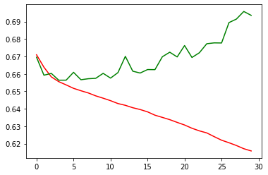

```python
model = Sequential()

# RNN
# 입력층 설정
model.add(GRU(32,input_shape=(2, 36)))

# 은닉층 추가
model.add(Dense(32, activation='relu'))
model.add(Dense(16, activation='relu'))

# 출력레이어
model.add(Dense(1, activation='sigmoid'))

# 설정
model.compile(optimizer='rmsprop', loss='binary_crossentropy', metrics='acc')

# 학습 (데이터를 분리하지 않은 상태에서 설정)
# 에포크: 반복 학습 횟수 - 너무 적으면 학습이 부족, 너무 많으면 과적합 위험 - 적절한 값 설정 필요
# batch_size: 1회의 에포크 내에서 데이터를 나누어 학습하는 크기-널리 쓰이는 값인 32로 설정
history = model.fit(train_x, train_y, epochs=30, batch_size=32, validation_split=0.2, callbacks=[es, mc])

plt.plot(history.history['loss'], c='r')
plt.plot(history.history['val_loss'], c='g')
```

```python
# 검증용 데이터로 loss/accuracy 재계산
model.evaluate(valid_x, valid_y) # loss, acc
```

```
[0.6972981095314026, 0.587959885597229]
```

validation loss의 변화를 살펴보면, 초기 0.6696에서 최소값인 0.6567까지 감소하였다가 이후 다시 증가하는 추세를 보인다. 이에 대한 원인을 살펴보면, 너무 큰 epoch에 의한 과적합이 발생했다고 볼 수 있다.

이에 대한 해결책으로, 에포크에 의한 val_loss변화를 모니터링하며 학습을 중단시키는 early stopping을 적용하였다. 또한, 최적의 모델을 저장하는 model checkpoint를 코드에 추가하였다.

적당한 은닉층의 갯수를 확인하기위해 은닉층을 더 추가한 후 다시 실행한 결과는 아래와 같다.

```python
from tensorflow.keras.callbacks import EarlyStopping, ModelCheckpoint
```

```
...
(중략)
...
Epoch 15: early stopping
```

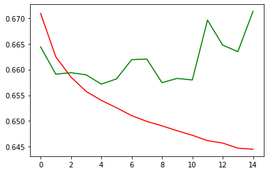

```python
model = Sequential()

# RNN
# 입력층 설정
model.add(GRU(32,input_shape=(2, 36)))

# 은닉층 추가
model.add(Dense(32, activation='relu'))
model.add(Dense(32, activation='relu'))
model.add(Dense(16, activation='relu'))
model.add(Dense(16, activation='relu'))

# 출력레이어
model.add(Dense(1, activation='sigmoid'))

# 설정
model.compile(optimizer='rmsprop', loss='binary_crossentropy', metrics='acc')

# Early Stopping
es = EarlyStopping(monitor='val_loss', mode='min', patience=10, verbose=1)

# Model CheckPoint
mc = ModelCheckpoint('clustering_gru_model.cp', monitor='val_loss', mode='min', save_best_only=True)

# 학습
history = model.fit(train_x, train_y, epochs=30, batch_size=32, validation_split=0.2, callbacks=[es, mc])

plt.plot(history.history['loss'], c='r')
plt.plot(history.history['val_loss'], c='g')
```

```python
from tensorflow.keras.models import load_model
```

```python
# 저장된 최적의 모델 로드
model = load_model('clustering_gru_model.cp')
# 검증용 데이터로 loss/accuracy 재계산
model.evaluate(valid_x, valid_y) # loss, acc
```

```
[0.6615767478942871, 0.6041436195373535]
```

#### RNN-LSTM

```
...
(중략)
...
Epoch 16: early stopping
```

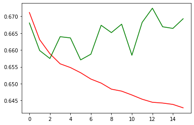

```python
model = Sequential()

# RNN
# 입력층 설정
model.add(LSTM(32,input_shape=(2, 36)))

# 은닉층 추가
model.add(Dense(32, activation='relu'))
model.add(Dense(32, activation='relu'))
model.add(Dense(16, activation='relu'))
model.add(Dense(16, activation='relu'))

# 출력레이어
model.add(Dense(1, activation='sigmoid'))

# 설정
model.compile(optimizer='rmsprop', loss='binary_crossentropy', metrics='acc')

# Early Stopping
es = EarlyStopping(monitor='val_loss', mode='min', patience=10, verbose=1)

# Model CheckPoint
mc = ModelCheckpoint('clustering_lstm_model.cp', monitor='val_loss', mode='min', save_best_only=True)

# 학습
history = model.fit(train_x, train_y, epochs=30, batch_size=32, validation_split=0.2, callbacks=[es, mc])

plt.plot(history.history['loss'], c='r')
plt.plot(history.history['val_loss'], c='g')
```

```python
# 저장된 최적의 모델 로드
model = load_model('clustering_lstm_model.cp')
# 검증용 데이터로 loss/accuracy 재계산
model.evaluate(valid_x, valid_y) # loss, acc
```

```
[0.6597630381584167, 0.602963924407959]
```

```python
# 실제 데이터와 예측결과 비교
pred = model(valid_x)
pred[5:10], valid_y[5:10] # 모델의 예측(확률값), 실제 게임 결과
```

```
(<tf.Tensor: shape=(5, 1), dtype=float32, numpy=
 array([[0.86748636],
        [0.5305397 ],
        [0.5465245 ],
        [0.23009111],
        [0.51252156]], dtype=float32)>,
 array([1, 1, 0, 0, 1]))
```

```python
len(pred)
```

```
27126
```

```python
# 모델이 70% 이상의 확률로 승 혹은 패를 예측한 경우
(pred>=0.7).numpy().sum(), (pred<=0.3).numpy().sum() # 승, 패로 각각 예측한 건수
```

```
(1609, 3487)
```

#### 모델 비교(loss/accuracy)

1. 첫번째 모델- GRU / early stopping 미적용 / 은닉층 2개
- 0.697, 0.588
1. 두번째 모델- GRU / early stopping 적용 / 은닉층 4개
- 0.662, 0.604
1. 세번째 모델- LSTM / early stopping 적용 / 은닉층 4개
- 0.660, 0.603

#### 모델 평가

첫번째 모델에 비해 early stopping을 통해 적절한 epoch값을 찾아서 적용한 모델들의 성능이 보다 좋은것을 확인 할 수 있었다. 반면, GRU와 LSTM의 성능차이는 확인하기 힘들었다.

모델에 사용한 알고리즘은 결과를 확률로써 예측하는데, 모델이 예측한 확률값이 0.3~0.7사이라면 강한 확신을 가지고 예측한것이라 생각하기 힘들다. 따라서 모델이 확신을 가지고 판단한 게임들의 건수를 조회해보니 약 5100여건 정도로 계산되었다. 이는 전체 검증데이터 건수에 20%도 미치지 못하는 수치로, 대부분의 경우에서 이번 모델은 확신을 갖고 예측하지 못하였다고 볼 수 있다.

모델의 손실함수 값은 0.66, 정확도는 0.60으로, 동전보다는 승패 예측을 잘 할 수 있다고 생각할 수도 있겠으나, 사실 동전을 던져도 정확도가 50%를 나온다는 점을 감안하면 큰 의미가 있는 모델이라고 해석하기엔 무리가 따른다. 모델을 튜닝한다면 약간의 성능 개선을 기대할 수는 있겠으나, 큰 향상을 기대하긴 힘들다고 보고 접근방식을 개선하기로 하였다.

#### 피드백

- 가설 검증의 가능성
  - 모델의 정확도가 높지 않았음에도, 챔피언의 구성에 기반하여 양 팀의 승리를 예측할 시 50%보다 높은 정확도를 보였음을 확인하였다. 이는 초기 가설이 여전히 가능성을 갖고 있음을 내포한다.
- 군집분석(비지도학습)의 한계
  - 정성적인 군집 평가
    - 결과를 객관적으로 확인 할 수 있는 수치화된 데이터가 없다보니, 일반적으로 널리 알려진 챔피언 분류에 기대어 정성적으로 평가 할 수 밖에 없었다. 이는 필연적으로 오차를 수반한다는 한계점이 존재한다.
  - 군집화로 인한 데이터 손실
    - 군잡화에 사용된 여러 속성들은 분명 챔피언별로 차이가 존재한다. 이는 심지어 같은 군집으로 분류된 챔피언들에게도 마찬가지로 적용되는 내용이다. 그러나 군집화결과로 새로 라벨링한 챔피언들은 같은 군집에 속해있다면 그 차이를 반영할 수가 없다.
- 대안
  - 가설이 유효할 가능성은 아직 상존한다. 그렇다면 모델의 성능이 저하된 가장 큰 원인은 군집화로 인한 데이터 손실이라고 생각된다. 이에 군집평가에 사용된 컬럼들을 대상으로 PCA분석을 하여 비교하기로 하였다.